# Characterizing Salmon Shed Tank Temperature, Conductivity, and Water Chemistry

Hello World

Author: OA Lab, NWFSC Title: Salmon Shed Tanks Date: 2018-2019 (R document January 2021)

# 1.) Setting Working Directory

# 2.) Creating the Dataframe

```
## [1] 381  22
```

Dataframes mentioned throughout the document dtank = SPEC sourced data dtankUDA= UDA sourced

SPECCNDCT conductivity measurements recording for SEPC UDACNDCT conductivity measurements recording from Honeywell UDA probe

# 3.) Creating dateTime objects

# 4.) Creating Treatments

# 5.) Salinity Dataframes

#### 5.1) Salinity Plots

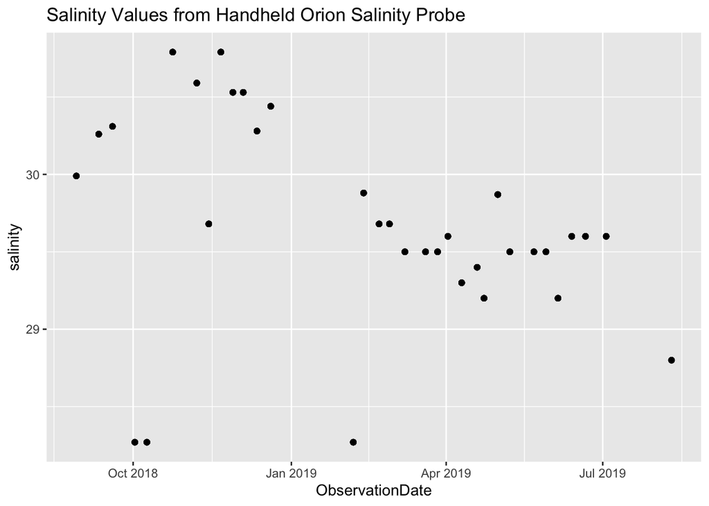

#### 5.1a) Merging salinity data for plots

```
## [1] 277  14
```

```
##  [1] "Date"            "T4.pH"           "T4.temp"         "T3.pH"
##  [5] "T3.temp"         "T5.pH"           "T5.temp"         "T6.pH"
##  [9] "T6.temp"         "T2.pH"           "T2.temp"         "T1.pH"
## [13] "T1.temp"         "Salinity"        "ObservationDate"
```

Determine if salinity units are both PSU

```r
names(dfSalinity)
```

```
## [1] "Date"              "Species"           "Tank"
## [4] "Water.Temperature" "Salinity"          "location"
## [7] "sensortype"        "ObservationDate"
```

```r
# [1] "Date"              "Species"           "Tank"              "Water.Temperature"
# [5] "salinity"          "location"          "sensortype"        "ObservationDate"

dfSalinity$Salinity <- as.numeric(dfSalinity$Salinity)
na.omit(dfSalinity, cols=salinity)
```

|  | Date | Species | Tank | Water.Temperature | Salinity | location | sensortype | ObservationDate |
| --- | --- | --- | --- | --- | --- | --- | --- | --- |
| 1 | 6/21/19 | Chum | N/A | 11.9 | 29.78 | salmonShed | HoneywellUDA | 2019-06-21 |
| 2 | 6/21/19 | Chinook | 1 | 12.3 | 29.77 | chumHouse | HoneywellUDA | 2019-06-21 |
| 3 | 6/21/19 | Chinook | 2 | 12 | 30.01 | chumHouse | HoneywellUDA | 2019-06-21 |
| 4 | 6/21/19 | Chinook | 3 | 12 | 30.01 | chumHouse | HoneywellUDA | 2019-06-21 |
| 5 | 6/21/19 | Chinook | 4 | 12 | 30.01 | chumHouse | HoneywellUDA | 2019-06-21 |
| 6 | 6/21/19 | Chinook | 5 | 12 | 30.00 | chumHouse | HoneywellUDA | 2019-06-21 |
| 7 | 6/21/19 | Chinook | 6 | 12 | 29.98 | chumHouse | HoneywellUDA | 2019-06-21 |
| 8 | 6/21/19 | Coho | 28 | 12 | 29.91 | salmonShed | HoneywellUDA | 2019-06-21 |
| 9 | 6/21/19 | Coho | 29 | 11.8 | 29.91 | salmonShed | HoneywellUDA | 2019-06-21 |
| 10 | 6/21/19 | Sable | N/A | 11.9 | 30.01 | salmonShed | HoneywellUDA | 2019-06-21 |

[output cut: 187 more lines]

```r
chronoSalinity1 <- subset(dfSalinity, select = -c(Species,
                                         Tank,
                                         Water.Temperature))

# chronoSalinity1 <- chronoSalinity1  %>% filter(location %in% c("salmonShed"))
# chronoSalinity1 <- subset( chronoSalinity1, select = -c(location))
#104 of 200 observations remaining if removing another other location


chronoSalinity1$Salinity
```

```
##   [1] 29.78 29.77 30.01 30.01 30.01 30.00 29.98 29.91 29.91 30.01 29.92 29.98
##  [13] 30.10 30.13 30.14 30.13 30.10 30.13 30.13 30.04 30.15 30.09 29.63 30.06
##  [25] 30.12 30.10 30.06 30.02 30.11 30.12 30.13 30.12 30.08 29.93 29.93 29.99
##  [37] 29.98 29.95 29.98 30.01 30.02 30.04 30.00 30.04 29.96 30.11 30.16 30.15
##  [49] 30.13 29.97 30.04 30.07 30.04 30.03 29.97 30.09 30.20 30.27 30.23 30.19
##  [61] 29.96 30.13 30.15 30.12 30.13 30.11 30.07 30.16 30.22 30.20 30.21 30.13
##  [73] 30.18 30.19 30.18 30.18 30.16 30.20 30.16 30.17 30.22 30.22 30.21 30.12
##  [85] 30.17 30.19 30.17 30.17 30.22 30.11 30.24 29.76 30.24 30.26 29.61 29.73
##  [97] 29.75 29.73 29.75 29.75 29.82 29.79 29.84 29.84 29.85 29.74 29.80 29.81
## [109] 29.82 29.79 29.81 29.70 29.74 29.76    NA    NA    NA 29.71 29.75 29.76
## [121] 29.89 29.90 29.92 29.91 29.91 29.91 29.84 29.63 29.89 29.74 29.85 29.87
## [133] 29.89 29.88 29.87 29.96 29.95 29.96 29.96 29.97 29.96 29.93 29.77 29.95
## [145] 29.88 29.92 29.91 29.92 29.94 29.94 29.99 29.98 30.00 30.02 30.00 29.99
## [157] 29.86 29.99 30.01 29.81 29.96 29.98 29.99 30.00 30.00 29.97 29.85 30.00
## [169] 29.82 29.99 29.89 29.97 29.85 29.92 29.98 29.87 30.00 30.00 30.00 29.99
## [181] 29.98 30.09 30.10 30.09 30.09 30.07 30.09 30.09 30.05 30.08 30.11 29.96
## [193] 30.06 30.08 30.07 30.07 30.09 29.63 29.71 29.80
```

```r
names(chronoSalinity1)[names(chronoSalinity1) == "Salinity"] <- "salinity"


dTankCNDCT
```

| salinity | ObservationDate | sensortype | treatName | treatpH | treatTemp | treatOther | dic | tankTemp |
| --- | --- | --- | --- | --- | --- | --- | --- | --- |
| 28.27 | 2018-10-02 | Orion | High pH | 7.8 | ambient | NA | 1897.914 | NA |
| 28.27 | 2018-10-02 | Orion | High pH | 7.8 | ambient | NA | 1895.622 | NA |
| 28.27 | 2018-10-02 | Orion | Low pH | 7.2 | ambient | NA | 2027.077 | NA |
| 28.27 | 2018-10-02 | Orion | Low pH | 7.2 | ambient | NA | 2035.323 | NA |
| 28.27 | 2018-10-02 | Orion | High pH | 7.8 | ambient | NA | 1895.622 | NA |
| 28.27 | 2018-10-02 | Orion | High pH | 7.8 | ambient | NA | 1893.436 | NA |
| 28.27 | 2018-10-02 | Orion | Low pH | 7.2 | ambient | NA | 2033.448 | NA |
| 28.27 | 2018-10-02 | Orion | Low pH | 7.2 | ambient | NA | 2033.448 | NA |
| 28.27 | 2018-10-02 | Orion | High pH | 7.8 | ambient | NA | 1900.496 | NA |
| 28.27 | 2018-10-02 | Orion | High pH | 7.8 | ambient | NA | 1894.808 | NA |

[output cut: 648 more lines]

```r
names(dTankCNDCT)
```

```
## [1] "salinity"        "ObservationDate" "sensortype"      "treatName"
## [5] "treatpH"         "treatTemp"       "treatOther"      "dic"
## [9] "tankTemp"
```

```r
# [1] "salinity"        "ObservationDate" "sensortype"      "treatName"       "treatpH"
# [6] "treatTemp"       "treatOther"      "dic"             "tankTemp"

chronoSalinity2 <- dTankCNDCT

chronoSalinity2 <- subset(chronoSalinity2, select = -c(sensortype,
                                         treatName,
                                         treatpH,
                                         treatTemp,
                                         treatOther,
                                         dic,
                                         tankTemp))

chronoSalinity2$sensortype <- ""
chronoSalinity2$sensortype <- "HoneywellUDA"

chronoSalinity2$location <- ""
chronoSalinity2$location <- "salmonShed"

chronoSalinity <- merge(chronoSalinity1, chronoSalinity2, all = TRUE)
```

[figure not shown]

```r
ggplot(chronoSalinity, aes(ObservationDate, salinity)) +
  geom_point(aes(colour=, point=)) +
  ggtitle("Salinity Values from All UDA observations in Salmon Shed")
```

#### 5.1b) Different Salinity Probes’ Data

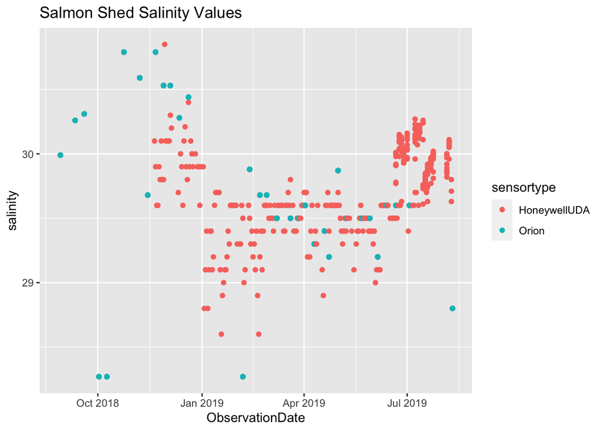

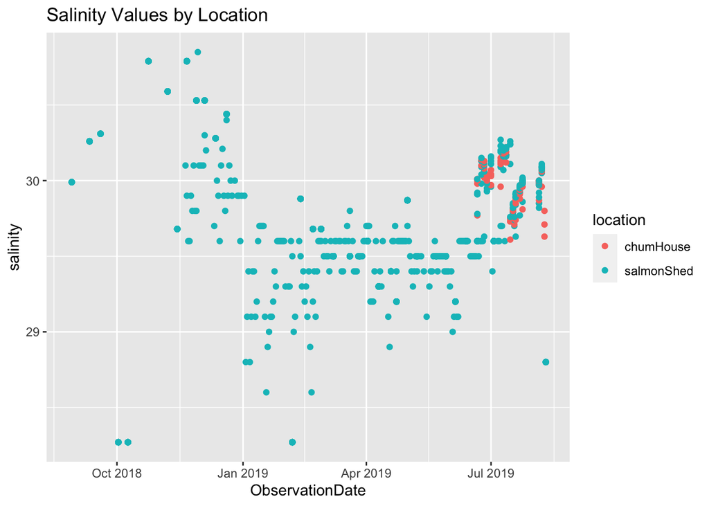

```r
PSUplot <- ggplot(dTANKConductivity, aes(x=ObservationDate, y=salinity)) +
  geom_point(aes(colour=location, point=)) +
  ggtitle("Salinity Values by Location")
PSUplot
```

# 6.) Water Chemistry

#### 6.1) pH plots per tank timeseries

#### 6.1a) pH plots -Timeseries Plots - UDA

```
## [1] "experiment"  "unit"        "unit_number" "date"        "pH"
## [6] "temp"
```

```
## [1] "experiment"  "unit"        "unit_number" "date"        "pH"
## [6] "temp"        "sensortype"
```

```
## [1] "experiment"      "unit"            "unit_number"     "date"
## [5] "pH"              "temp"            "sensortype"      "ObservationDate"
```

#### 6.2a) pH plots -Timeseries Plots - UDA sensor log filtered

```
## [1] "experiment"      "unit"            "unit_number"     "date"
## [5] "pH"              "temp"            "sensortype"      "ObservationDate"
```

```
## [1] "unit_number"     "pH"              "sensortype"      "ObservationDate"
## [5] "treatment"
```

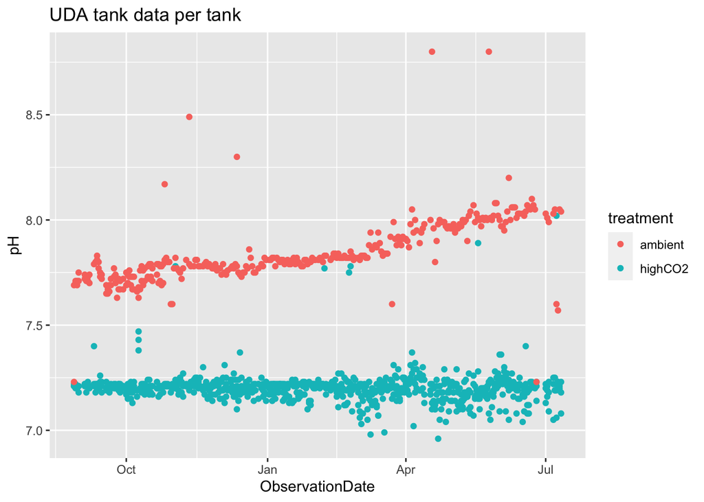

#### 6.3a) UDA tank data per tank (Tank 5 Early Problem Start Relay Problems) (Filtered 5-10 pH)

Tank 5 has early problem start problems (Data from Honeywell UDA sensor & display)

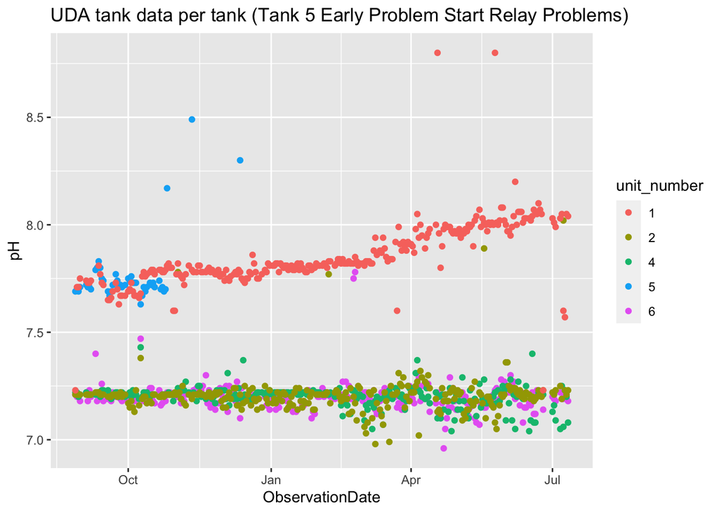

#### 6.3b) UDA tank data per tank (Filtered to show 6-8 pH)

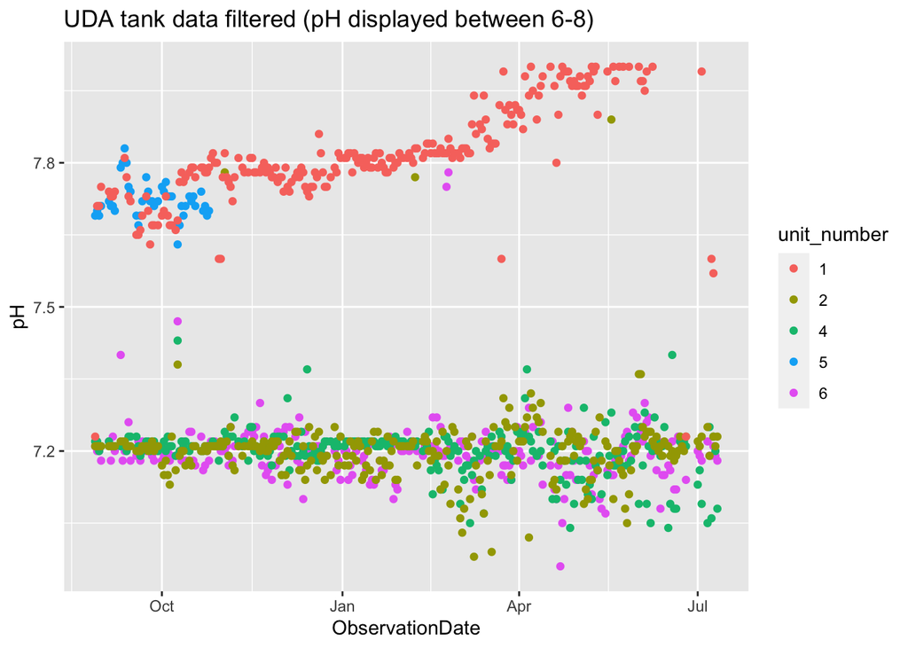

Appears that all Probes got “tired” after April Tank 01’s probe experienced exceptional drift

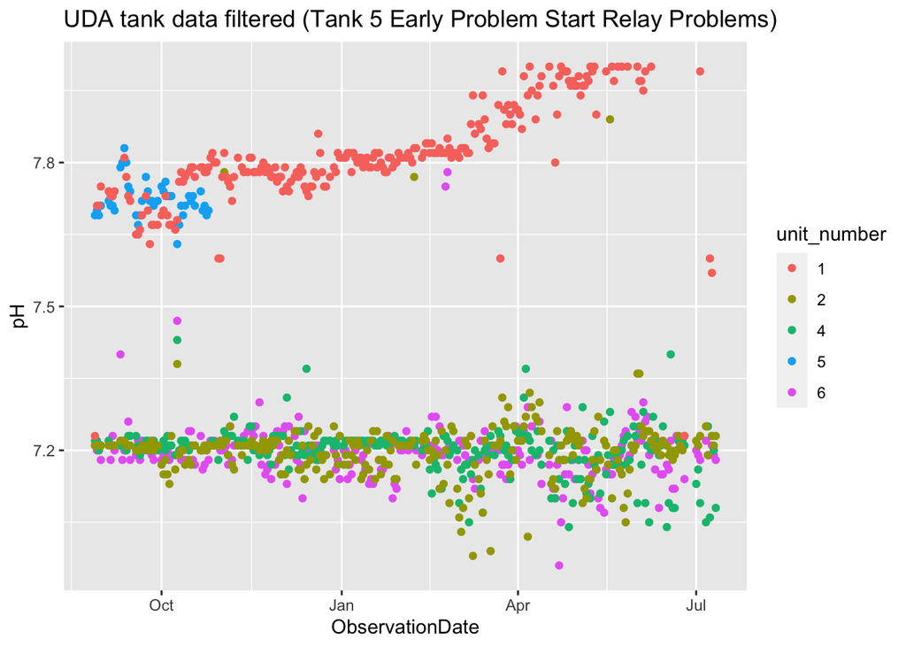

#### 6.4a) pH plots -Timeseries Plots - SPEC data

```
##  [1] "experiment"      "unit"            "unit_number"     "id_1"
##  [5] "id_2"            "id_3"            "time"            "date"
##  [9] "salinity"        "pHat25"          "fileName"        "unit_ID"
## [13] "alk"             "insituTemp"      "pHinsitu"        "dateString"
## [17] "treatName"       "treatpH"         "treatTemp"       "treatOther"
## [21] "dic"             "tankTemp"        "ObservationDate" "treatment"
```

```
##  [1] "unit_number"     "pHinsitu"        "treatName"       "treatpH"
##  [5] "treatTemp"       "treatOther"      "dic"             "tankTemp"
##  [9] "ObservationDate" "treatment"
```

```
##  [1] "unit_number"     "pH"              "treatName"       "treatpH"
##  [5] "treatTemp"       "treatOther"      "dic"             "tankTemp"
##  [9] "ObservationDate" "treatment"
```

```
## [1] 1766   11
```

```
##  [1] "unit_number"     "pH"              "ObservationDate" "treatment"
##  [5] "sensortype"      "treatName"       "treatpH"         "treatTemp"
##  [9] "treatOther"      "dic"             "tankTemp"
```

#### 6.4b) Water Chemistry Plots between different probe types

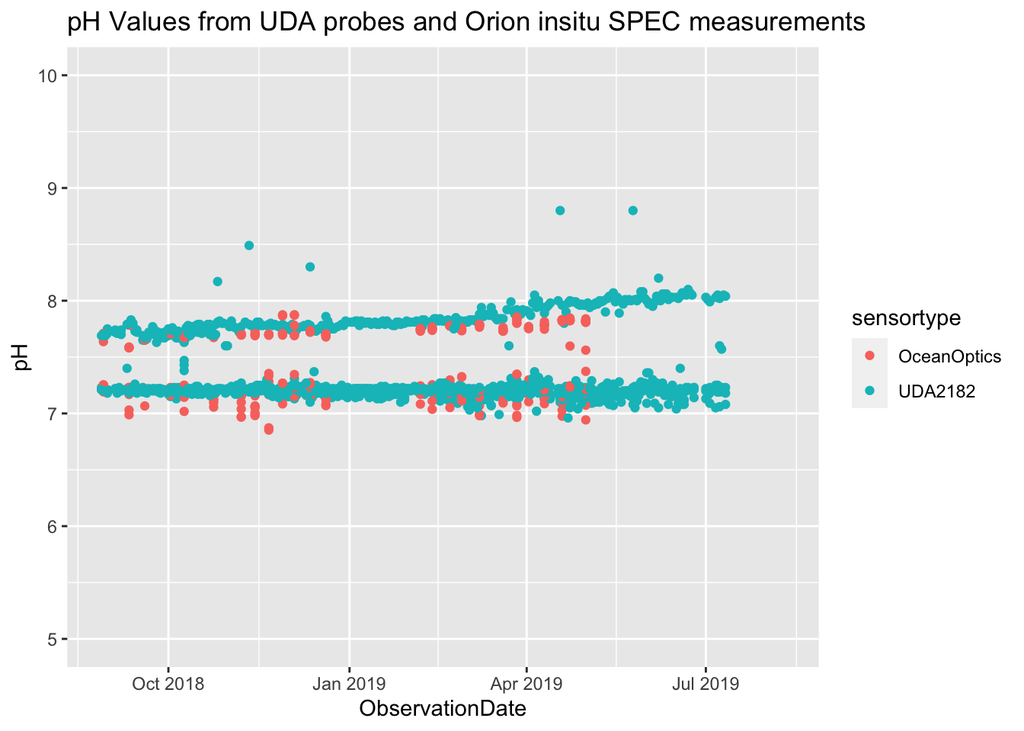

```r
pHplot1 <- ggplot(pHtanklog, aes(x=ObservationDate, y=pH)) +
  geom_point(aes(colour=sensortype, point=)) +
  ylim(5,10) +
  ggtitle("pH Values from UDA probes and Orion insitu SPEC measurements")
pHplot1
```

#### 6.5c Water Chemistry Plots between different treatment timeseries

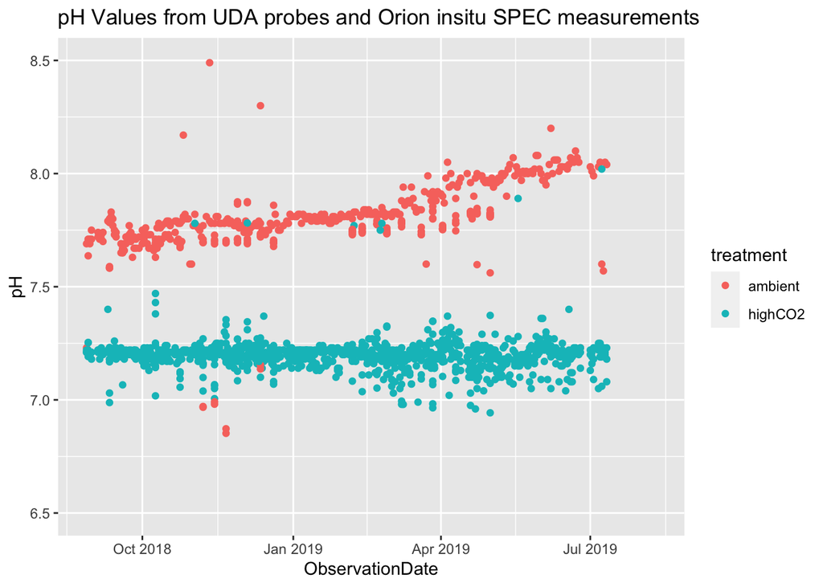

```r
pHplot2 <- ggplot(pHtanklog, aes(x=ObservationDate, y=pH)) +
  geom_point(aes(colour=treatment, point=)) +
  ylim(6.5,8.5) +
  ggtitle("pH Values from UDA probes and Orion insitu SPEC measurements")
pHplot2
```

# Executive Summary

UDA sensors for ambient tank 01 appears to experience significant drift April and beyond. Chase’s UDA data could confirm if pH drift was actual, was a real world seasonal effect SPEC data confirms the High CO2 treatment target pH.

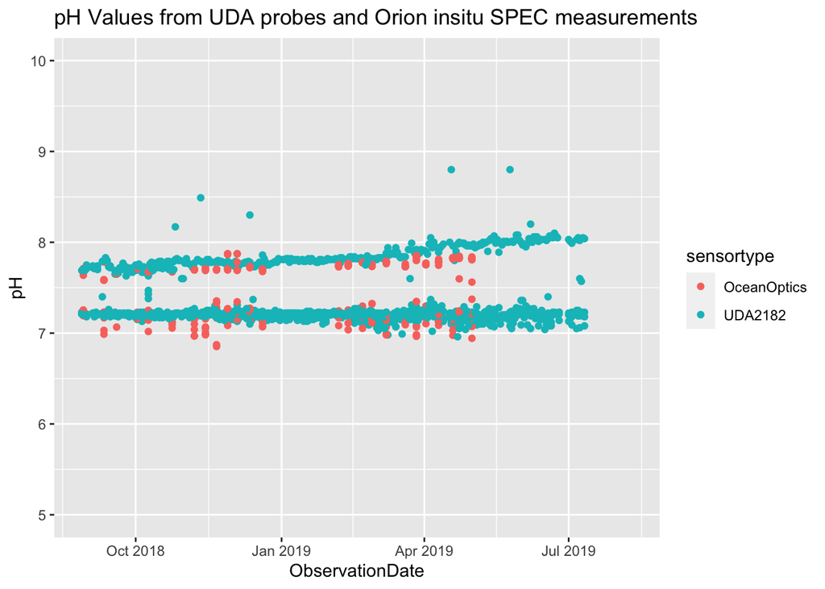

```r
pHplot1
```

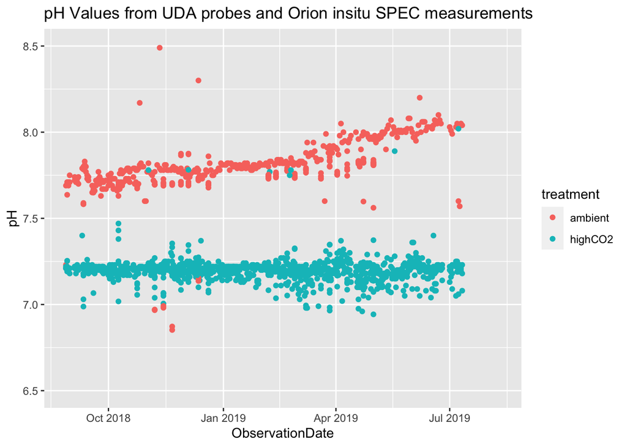

```r
pHplot2
```

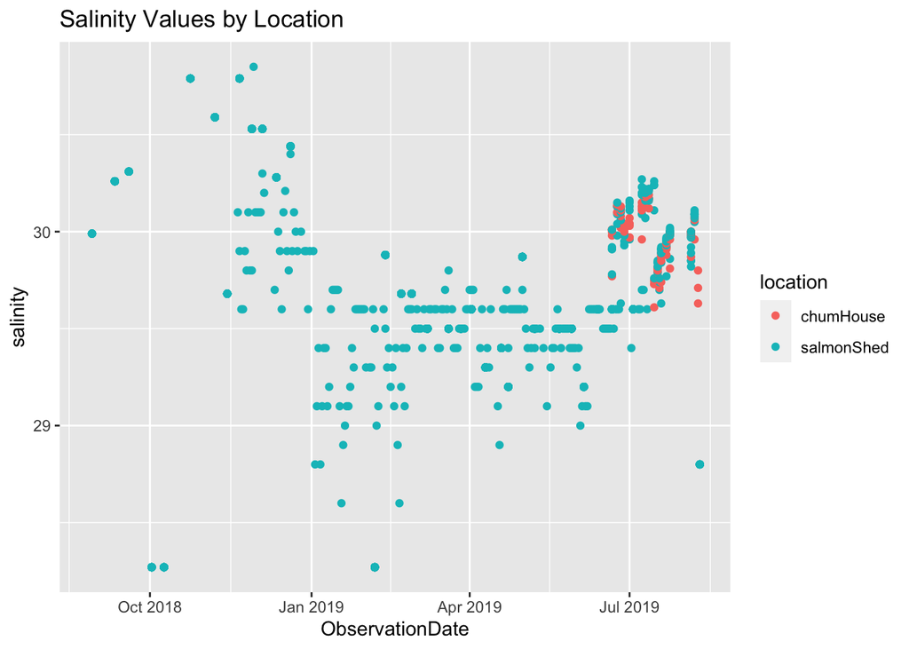

```r
PSUplot
```

```r
pHtanklog.summary <- pHtanklog %>% group_by(treatment, sensortype) %>%
  dplyr::summarize(sd = sd(pH, na.rm = TRUE),
            mean = mean(pH, na.rm = TRUE),
            median = median(pH, na.rm = TRUE),
            IQR = IQR(pH, na.rm = TRUE),
            n = n()) %>%
  mutate(se = sd/sqrt(n)) %>%
  mutate(ci = se*1.96)
write.csv(pHtanklog.summary, "2021.02.02_pHtanklog.summary.csv")
kable(pHtanklog.summary, digits = 4)
```

| treatment | sensortype | sd | mean | median | IQR | n | se | ci |
| --- | --- | --- | --- | --- | --- | --- | --- | --- |
| ambient | OceanOptics | 0.1839 | 7.7030 | 7.7343 | 0.0888 | 190 | 0.0133 | 0.0262 |
| ambient | UDA2182 | 2.0751 | 8.2560 | 7.8100 | 0.2400 | 554 | 0.0882 | 0.1728 |
| highCO2 | OceanOptics | 0.0999 | 7.1677 | 7.1707 | 0.1009 | 191 | 0.0072 | 0.0142 |
| highCO2 | UDA2182 | 0.2469 | 7.2095 | 7.2100 | 0.0400 | 831 | 0.0086 | 0.0168 |

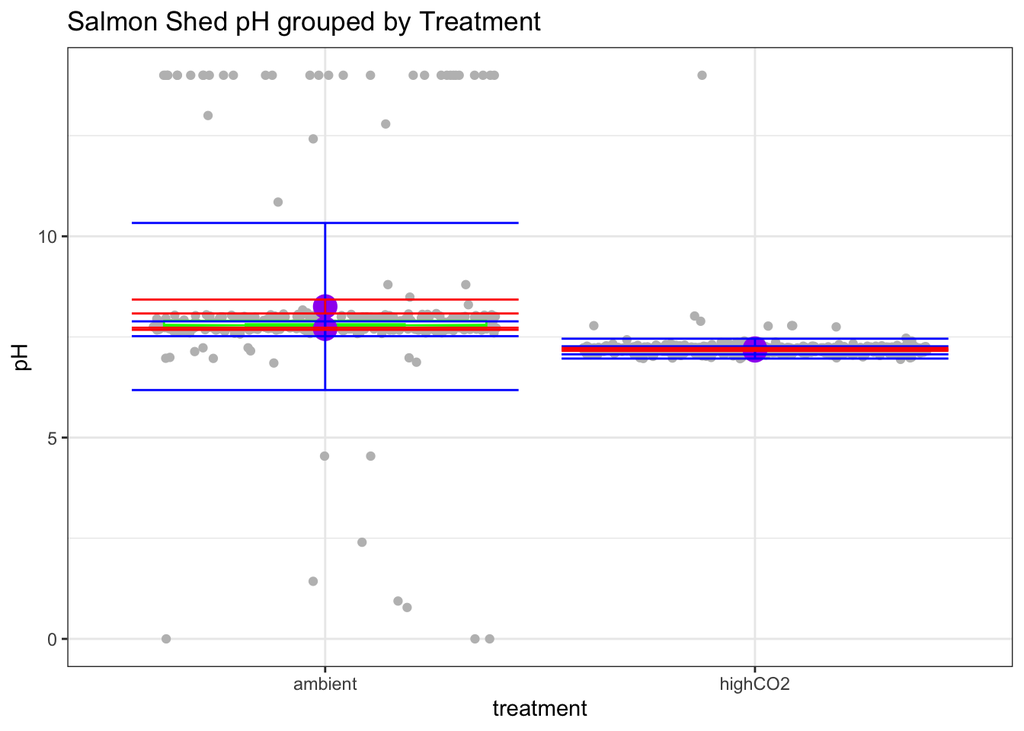

```r
pHboxplots1 <- ggplot(pHtanklog, aes(treatment, pH)) +
            geom_jitter(color = "grey") +
            geom_boxplot(notch = TRUE, outlier.shape = NA, colour = "green") +
            geom_point(data = pHtanklog.summary, aes(x=treatment, y=mean), size=5, color = "purple") +
            geom_errorbar(data = pHtanklog.summary,
                          aes(x=treatment, y=mean, ymin = mean-sd, ymax = mean+sd),
                          color = "blue") +
            geom_errorbar(data = pHtanklog.summary,
                          aes(x=treatment, y=mean, ymin = mean-ci, ymax = mean+ci),
                          colour = "red") +
            # facet_wrap(~TrialID) +
            ggtitle("Salmon Shed pH grouped by Treatment") +
            theme_bw()

pHboxplots1
```

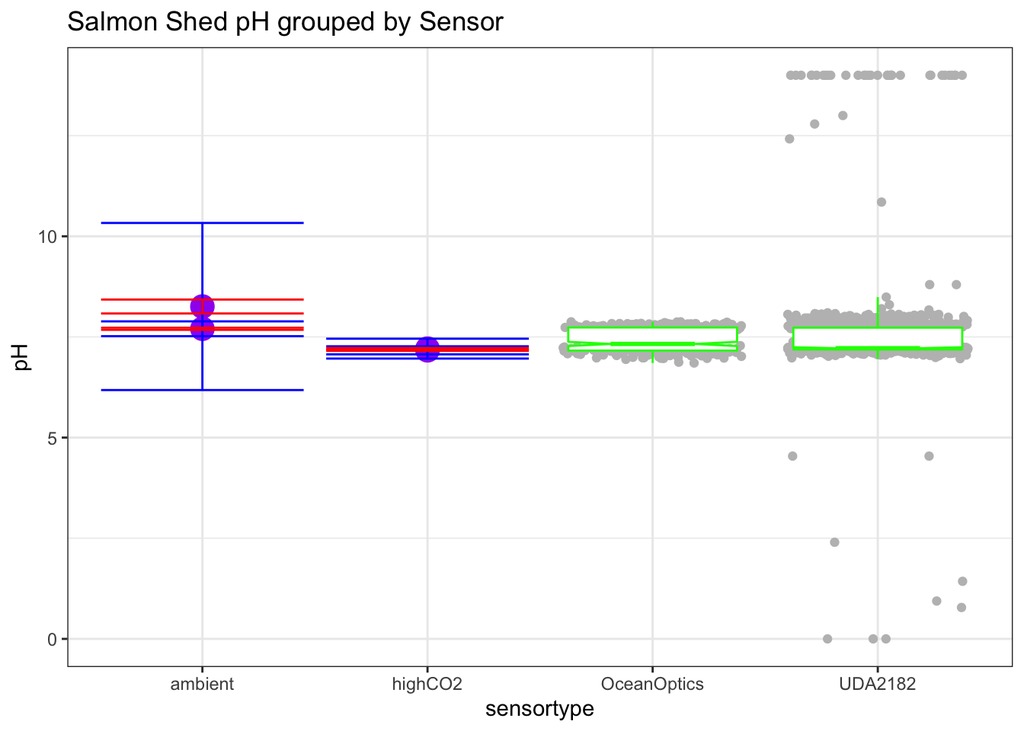

```r
pHboxplots2 <- ggplot(pHtanklog, aes(sensortype, pH)) +
            geom_jitter(color = "grey") +
            geom_boxplot(notch = TRUE, outlier.shape = NA, colour = "green") +
            geom_point(data = pHtanklog.summary, aes(x=treatment, y=mean), size=5, color = "purple") +
            geom_errorbar(data = pHtanklog.summary,
                          aes(x=treatment, y=mean, ymin = mean-sd, ymax = mean+sd),
                          color = "blue") +
            geom_errorbar(data = pHtanklog.summary,
                          aes(x=treatment, y=mean, ymin = mean-ci, ymax = mean+ci),
                          colour = "red") +
            # facet_wrap(~TrialID) +
            ggtitle("Salmon Shed pH grouped by Sensor") +
            theme_bw()

pHboxplots2
```

```r
#**************E*N*D*************#
#*********************************
## END OF SCRIPT | END OF DOCUMENT
#*********************************
```

## END OF SCRIPT | END OF DOCUMENT